# 02_hug_vs_ebm_clean_axes

## HUG-IML versus Explainable Boosting Machine

### Pattern inventory, bin-profile evidence, EBM shape functions, and local explanations on a common clinical classification task.

This notebook compares two interpretable supervised models trained on the same data split:

- **HUG-IML** represents evidence as discrete interval patterns. A fired pattern contributes a learned coefficient to the prediction.
- **Explainable Boosting Machine (EBM)** represents evidence as additive feature and interaction shape functions.

The review emphasizes not only predictive metrics, but also whether the two explanation systems tell compatible stories. HUG bin profiles are placed next to EBM shape functions so that thresholded pattern evidence can be reviewed against smooth additive effects.

```python
import warnings
warnings.filterwarnings("ignore")

import re
import numpy as np
import pandas as pd
import matplotlib.pyplot as plt
from matplotlib.ticker import FuncFormatter

from sklearn.datasets import load_breast_cancer
from sklearn.model_selection import train_test_split
from sklearn.metrics import (
    roc_auc_score,
    average_precision_score,
    balanced_accuracy_score,
    log_loss,
    brier_score_loss,
    RocCurveDisplay,
)
from sklearn.calibration import calibration_curve

from hugiml import HUGIMLClassifier
from interpret.glassbox import ExplainableBoostingClassifier

RANDOM_STATE = 42
pd.set_option("display.max_colwidth", 160)
pd.set_option("display.float_format", lambda x: f"{x:,.4f}")

PALETTE = {
    "hug": "#0f766e",
    "ebm": "#1d4ed8",
    "neutral": "#334155",
    "muted": "#64748b",
    "accent": "#f59e0b",
    "risk": "#be123c",
    "surface": "#f8fafc",
}

plt.rcParams.update({
    "figure.facecolor": "white",
    "axes.facecolor": PALETTE["surface"],
    "axes.edgecolor": "#94a3b8",
    "axes.grid": True,
    "grid.alpha": 0.24,
    "axes.titleweight": "bold",
    "axes.titlesize": 11,
    "font.size": 9.5,
})
```

## 1. Dataset and common split

The target is encoded as `1 = benign`. Both models receive identical training rows and are evaluated on identical held-out rows.

```python
data = load_breast_cancer(as_frame=True)
X = data.data.copy()
y = pd.Series(data.target, name="benign")

X_train, X_test, y_train, y_test = train_test_split(
    X, y, test_size=0.25, stratify=y, random_state=RANDOM_STATE
)

summary = pd.DataFrame({
    "partition": ["train", "test", "overall"],
    "rows": [len(X_train), len(X_test), len(X)],
    "positive_rate_benign": [y_train.mean(), y_test.mean(), y.mean()],
    "features": [X_train.shape[1], X_test.shape[1], X.shape[1]],
})
summary
```

|  | partition | rows | positive_rate_benign | features |
| --- | --- | --- | --- | --- |
| 0 | train | 426 | 0.6268 | 30 |
| 1 | test | 143 | 0.6294 | 30 |
| 2 | overall | 569 | 0.6274 | 30 |

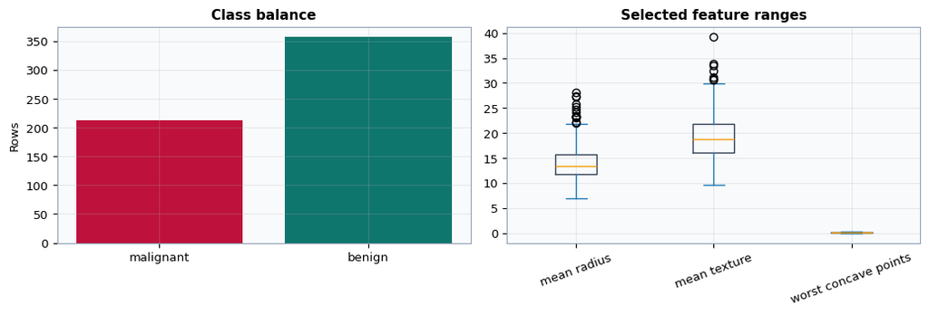

```python
fig, axes = plt.subplots(1, 2, figsize=(10.5, 3.6))
class_counts = y.value_counts().sort_index().rename(index={0: "malignant", 1: "benign"})
axes[0].bar(class_counts.index, class_counts.values, color=[PALETTE["risk"], PALETTE["hug"]])
axes[0].set_title("Class balance")
axes[0].set_ylabel("Rows")
axes[0].tick_params(axis="x", rotation=0)

sample_features = ["mean radius", "mean texture", "worst concave points"]
X[sample_features].plot(kind="box", ax=axes[1], color={"boxes": PALETTE["neutral"], "medians": PALETTE["accent"]})
axes[1].set_title("Selected feature ranges")
axes[1].tick_params(axis="x", rotation=20)
plt.tight_layout()
plt.show()
```

## 2. Train HUG-IML

HUG-IML learns interval-based patterns. Coefficients indicate how much a fired pattern moves the prediction toward or away from the benign class.

```python
hug = HUGIMLClassifier(B=8, L=2, G=2e-3, topK=120)
hug.fit(X_train, y_train)

hug_score = hug.predict_proba(X_test)[:, 1]
hug_pred = (hug_score >= 0.5).astype(int)

print(hug.model_summary())
```

```
HUGIMLClassifierNative — Model Summary
==================================================
Config:       B=8, L=2, G=0.002
Training:     426 samples, 30 features, 2 classes
Patterns:     120 (0 compound)
Matrix:       (426, 120) (density=0.1252)
Fit time:     622 ms

Stage breakdown (ms):
  resolve_meta                  14.8
  prepare_transactions         445.2
  mine_patterns                 67.5
  build_matrix                   2.2
  fit_downstream                 9.8
  compat                         3.0

Top 10 patterns by importance:
  mean texture=[9.71,14.63)                coef= +1.1517  sup=0.127
  worst smoothness=[0.07117,0.1069)        coef= +1.1512  sup=0.127
  worst concave points=[0.2023,0.291)      coef= -1.1103  sup=0.127
  worst texture=[18.32,21.06)              coef= +1.0895  sup=0.124
  worst concave points=[0.1627,0.2023)     coef= -1.0275  sup=0.124
  worst texture=[12.02,18.32)              coef= +0.9991  sup=0.127
  mean texture=[14.63,15.99)               coef= +0.9598  sup=0.124
  mean concave points=[0.07411,0.09553)    coef= -0.9556  sup=0.124
  compactness error=[0.009765,0.01271)     coef= -0.9145  sup=0.124
  worst radius=[18.55,22.62)               coef= -0.8975  sup=0.127

NaN handling: 30 numerical column(s) pre-binned (NaN/Inf generates no transaction item at train or test time).
```

## 3. Train Explainable Boosting Machine

The comparator is a real `interpret.glassbox.ExplainableBoostingClassifier`. The configuration is deterministic and keeps training compact while still allowing a small set of pairwise interactions.

```python
ebm = ExplainableBoostingClassifier(
    random_state=RANDOM_STATE,
    interactions=3,
    max_rounds=80,
    learning_rate=0.04,
    n_jobs=1,
)
ebm.fit(X_train, y_train)

ebm_score = ebm.predict_proba(X_test)[:, 1]
ebm_pred = (ebm_score >= 0.5).astype(int)

print(f"Trained EBM terms: {len(ebm.term_names_)}")
print("First terms:", ebm.term_names_[:8])
```

```
Trained EBM terms: 33
First terms: ['mean radius', 'mean texture', 'mean perimeter', 'mean area', 'mean smoothness', 'mean compactness', 'mean concavity', 'mean concave points']
```

## 4. Predictive comparison

Metrics are computed on the same holdout partition. The compact display groups rank metrics and probability-quality metrics side by side.

```python
def score_row(name, proba, pred):
    return {
        "model": name,
        "roc_auc": roc_auc_score(y_test, proba),
        "avg_precision": average_precision_score(y_test, proba),
        "balanced_accuracy": balanced_accuracy_score(y_test, pred),
        "log_loss": log_loss(y_test, proba),
        "brier_score": brier_score_loss(y_test, proba),
    }

perf = pd.DataFrame([
    score_row("HUG-IML", hug_score, hug_pred),
    score_row("EBM", ebm_score, ebm_pred),
])
perf
```

|  | model | roc_auc | avg_precision | balanced_accuracy | log_loss | brier_score |
| --- | --- | --- | --- | --- | --- | --- |
| 0 | HUG-IML | 0.9851 | 0.9905 | 0.9456 | 0.1270 | 0.0356 |
| 1 | EBM | 0.9962 | 0.9977 | 0.9645 | 0.0765 | 0.0228 |

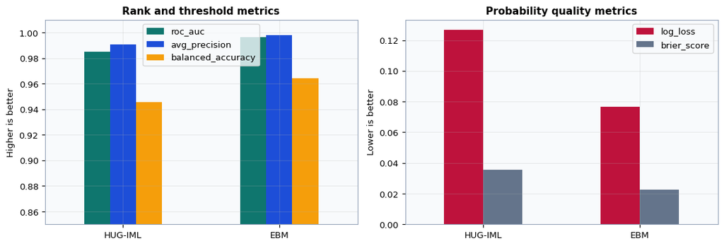

```python
fig, axes = plt.subplots(1, 2, figsize=(11.0, 3.8))
rank_metrics = ["roc_auc", "avg_precision", "balanced_accuracy"]
loss_metrics = ["log_loss", "brier_score"]
perf.set_index("model")[rank_metrics].plot(kind="bar", ax=axes[0], color=[PALETTE["hug"], PALETTE["ebm"], PALETTE["accent"]])
axes[0].set_ylim(0.85, 1.01)
axes[0].set_title("Rank and threshold metrics")
axes[0].set_xlabel("")
axes[0].set_ylabel("Higher is better")
axes[0].tick_params(axis="x", rotation=0)

perf.set_index("model")[loss_metrics].plot(kind="bar", ax=axes[1], color=[PALETTE["risk"], PALETTE["muted"]])
axes[1].set_title("Probability quality metrics")
axes[1].set_xlabel("")
axes[1].set_ylabel("Lower is better")
axes[1].tick_params(axis="x", rotation=0)
plt.tight_layout()
plt.show()
```

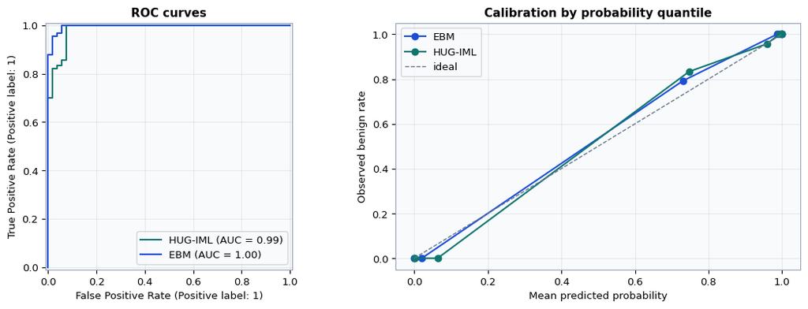

|  | model | quantile_bin | mean_predicted | observed_rate |
| --- | --- | --- | --- | --- |
| 0 | HUG-IML | 1 | 0.0013 | 0.0000 |
| 1 | HUG-IML | 2 | 0.0637 | 0.0000 |
| 2 | HUG-IML | 3 | 0.7474 | 0.8333 |
| 3 | HUG-IML | 4 | 0.9582 | 0.9565 |
| 4 | HUG-IML | 5 | 0.9924 | 1.0000 |
| 5 | HUG-IML | 6 | 0.9983 | 1.0000 |
| 6 | EBM | 1 | 0.0000 | 0.0000 |
| 7 | EBM | 2 | 0.0206 | 0.0000 |
| 8 | EBM | 3 | 0.7302 | 0.7917 |
| 9 | EBM | 4 | 0.9865 | 1.0000 |
| 10 | EBM | 5 | 0.9989 | 1.0000 |
| 11 | EBM | 6 | 1.0000 | 1.0000 |

```python
cal_rows = []
for name, score in [("HUG-IML", hug_score), ("EBM", ebm_score)]:
    frac_pos, mean_pred = calibration_curve(y_test, score, n_bins=6, strategy="quantile")
    for idx in range(len(mean_pred)):
        cal_rows.append({"model": name, "quantile_bin": idx + 1, "mean_predicted": mean_pred[idx], "observed_rate": frac_pos[idx]})
cal_df = pd.DataFrame(cal_rows)

fig, axes = plt.subplots(1, 2, figsize=(11.2, 4.1))
RocCurveDisplay.from_predictions(y_test, hug_score, name="HUG-IML", ax=axes[0], color=PALETTE["hug"])
RocCurveDisplay.from_predictions(y_test, ebm_score, name="EBM", ax=axes[0], color=PALETTE["ebm"])
axes[0].set_title("ROC curves")

for name, df in cal_df.groupby("model"):
    color = PALETTE["hug"] if name == "HUG-IML" else PALETTE["ebm"]
    axes[1].plot(df["mean_predicted"], df["observed_rate"], marker="o", label=name, color=color)
axes[1].plot([0, 1], [0, 1], linestyle="--", linewidth=1, label="ideal", color=PALETTE["muted"])
axes[1].set_title("Calibration by probability quantile")
axes[1].set_xlabel("Mean predicted probability")
axes[1].set_ylabel("Observed benign rate")
axes[1].legend()
plt.tight_layout()
plt.show()

cal_df
```

## 5. Global explanation inventories

The first inventory is pattern-based: HUG reports direct conditions and their coefficients. The second inventory is term-based: EBM reports average absolute additive contribution by feature or interaction term.

```python
def ebm_term_importance_table(ebm_model):
    rows = []
    for term_index, term in enumerate(ebm_model.term_names_):
        scores_arr = np.asarray(ebm_model.term_scores_[term_index], dtype=float).ravel()
        weights_arr = np.asarray(ebm_model.bin_weights_[term_index], dtype=float).ravel()
        n = min(scores_arr.size, weights_arr.size)
        if n == 0 or weights_arr[:n].sum() <= 0:
            importance = float(np.mean(np.abs(scores_arr))) if scores_arr.size else 0.0
        else:
            importance = float(np.average(np.abs(scores_arr[:n]), weights=weights_arr[:n]))
        rows.append({"term": term, "importance": importance})
    return pd.DataFrame(rows).sort_values("importance", ascending=False)

pattern_table = hug.get_pattern_info().merge(
    hug.feature_importances()[["pattern", "coefficient", "abs_coefficient", "support"]].rename(columns={"support": "model_support"}),
    on="pattern",
    how="left",
).sort_values("abs_coefficient", ascending=False)

ebm_importance = ebm_term_importance_table(ebm)

display(pattern_table.head(12))
display(ebm_importance.head(12))
```

|  | pattern | utility | information_gain | support | coefficient | abs_coefficient | model_support |
| --- | --- | --- | --- | --- | --- | --- | --- |
| 74 | mean texture=[9.71,14.63) | 28.4913 | 0.0492 | 0.1268 | 1.1517 | 1.1517 | 0.1268 |
| 78 | worst smoothness=[0.07117,0.1069) | 28.4913 | 0.0492 | 0.1268 | 1.1512 | 1.1512 | 0.1268 |
| 30 | worst concave points=[0.2023,0.291) | 5.8932 | 0.2034 | 0.1268 | -1.1103 | 1.1103 | 0.1268 |
| 81 | worst texture=[18.32,21.06) | 31.7298 | 0.0555 | 0.1244 | 1.0895 | 1.0895 | 0.1244 |
| 15 | worst concave points=[0.1627,0.2023) | 4.6955 | 0.1642 | 0.1244 | -1.0275 | 1.0275 | 0.1244 |
| 77 | worst texture=[12.02,18.32) | 28.4913 | 0.0492 | 0.1268 | 0.9991 | 0.9991 | 0.1268 |
| 67 | mean texture=[14.63,15.99) | 23.3024 | 0.0407 | 0.1244 | 0.9598 | 0.9598 | 0.1244 |
| 14 | mean concave points=[0.07411,0.09553) | 4.6955 | 0.1642 | 0.1244 | -0.9556 | 0.9556 | 0.1244 |
| 35 | compactness error=[0.009765,0.01271) | 7.4292 | 0.0130 | 0.1244 | -0.9145 | 0.9145 | 0.1244 |
| 21 | worst radius=[18.55,22.62) | 5.3138 | 0.1834 | 0.1268 | -0.8975 | 0.8975 | 0.1268 |
| 19 | worst area=[1034,1587) | 5.1275 | 0.1793 | 0.1244 | -0.8847 | 0.8847 | 0.1244 |
| 110 | worst concave points=[0.0432,0.06353) | 52.2421 | 0.0913 | 0.1244 | 0.8230 | 0.8230 | 0.1244 |

|  | term | importance |
| --- | --- | --- |
| 21 | worst texture | 0.7026 |
| 23 | worst area | 0.6105 |
| 27 | worst concave points | 0.5789 |
| 20 | worst radius | 0.5784 |
| 22 | worst perimeter | 0.5486 |
| 1 | mean texture | 0.5412 |
| 7 | mean concave points | 0.5244 |
| 13 | area error | 0.4687 |
| 24 | worst smoothness | 0.4682 |
| 32 | worst area & worst smoothness | 0.4096 |
| 26 | worst concavity | 0.3899 |
| 28 | worst symmetry | 0.3785 |

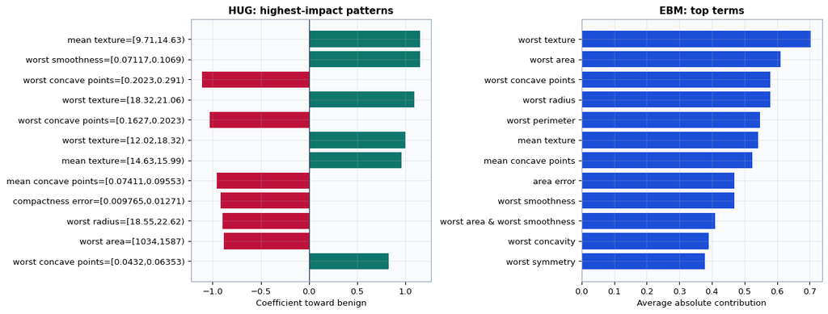

```python
fig, axes = plt.subplots(1, 2, figsize=(13.0, 5.0))
hug_plot = pattern_table.head(12).iloc[::-1]
ebm_plot = ebm_importance.head(12).iloc[::-1]
axes[0].barh(hug_plot["pattern"], hug_plot["coefficient"], color=np.where(hug_plot["coefficient"] >= 0, PALETTE["hug"], PALETTE["risk"]))
axes[0].axvline(0, linewidth=1, color=PALETTE["neutral"])
axes[0].set_title("HUG: highest-impact patterns")
axes[0].set_xlabel("Coefficient toward benign")
axes[0].set_ylabel("")

axes[1].barh(ebm_plot["term"], ebm_plot["importance"], color=PALETTE["ebm"])
axes[1].set_title("EBM: top terms")
axes[1].set_xlabel("Average absolute contribution")
axes[1].set_ylabel("")
plt.tight_layout()
plt.show()
```

## 6. HUG bin profiles versus EBM shape functions

This is the central interpretability comparison. For the same features, the left panels show **HUG bin profiles**: training rows are grouped into empirical quantile bins, and each bin summarizes the average HUG pattern contribution involving that feature. The right panels show the corresponding **EBM shape function** for the same feature. Positive values push toward benign; negative values push away from benign.

```python
def extract_feature_from_pattern(pattern, feature_names):
    matched = [name for name in feature_names if pattern.startswith(name + "=") or (name + "=") in pattern]
    return max(matched, key=len) if matched else None

hug_fi = hug.feature_importances().copy()
hug_fi["feature"] = hug_fi["pattern"].apply(lambda p: extract_feature_from_pattern(p, list(X.columns)))
hug_feature_importance = (
    hug_fi.dropna(subset=["feature"])
    .groupby("feature", as_index=False)["abs_coefficient"]
    .sum()
    .sort_values("abs_coefficient", ascending=False)
)

single_ebm_terms = [t for t in ebm_importance["term"] if t in X.columns]
common_features = [f for f in single_ebm_terms if f in set(hug_feature_importance["feature"])]
# Prefer features that matter to both systems.
feature_rank = pd.DataFrame({"feature": common_features}).merge(hug_feature_importance, on="feature", how="left")
feature_rank = feature_rank.merge(ebm_importance.rename(columns={"term": "feature", "importance": "ebm_importance"}), on="feature", how="left")
feature_rank["joint_rank_score"] = feature_rank["abs_coefficient"].rank(ascending=False) + feature_rank["ebm_importance"].rank(ascending=False)
features_for_shape_review = feature_rank.sort_values("joint_rank_score")["feature"].head(2).tolist()
features_for_shape_review
```

```
['worst concave points', 'worst area']
```

```python
def clean_number_label(value):
    """Format numeric axis labels without unnecessary scientific notation."""
    try:
        numeric = float(value)
    except (TypeError, ValueError):
        return str(value)
    if not np.isfinite(numeric):
        return str(value)
    abs_value = abs(numeric)
    if abs_value == 0:
        return "0"
    if abs_value >= 1000:
        text = f"{numeric:,.0f}" if np.isclose(numeric, round(numeric)) else f"{numeric:,.1f}"
    elif abs_value >= 100:
        text = f"{numeric:.1f}"
    elif abs_value >= 10:
        text = f"{numeric:.2f}"
    elif abs_value >= 1:
        text = f"{numeric:.2f}"
    elif abs_value >= 0.01:
        text = f"{numeric:.3f}"
    else:
        text = f"{numeric:.4f}"
    return text.rstrip("0").rstrip(".")

def clean_tick_label(value):
    """Clean scalar or interval labels returned by EBM without changing their meaning."""
    if isinstance(value, (int, float, np.integer, np.floating)):
        return clean_number_label(value)
    text = str(value)
    # Replace numeric tokens, including values such as 1.23e+04, with plain-number labels.
    return re.sub(
        r"(?<![A-Za-z])[-+]?\d*\.?\d+(?:[eE][-+]?\d+)?",
        lambda m: clean_number_label(m.group(0)),
        text,
    )

def clean_range_label(left, right):
    return f"{clean_number_label(left)}–{clean_number_label(right)}"

def hug_bin_profile(feature, n_bins=8):
    patterns_for_feature = hug_fi.loc[hug_fi["feature"] == feature, ["pattern", "coefficient"]]
    if patterns_for_feature.empty:
        raise ValueError(f"No HUG patterns found for {feature}")
    hug_feature_matrix = pd.DataFrame(
        hug.transform(X_train).toarray(),
        columns=np.array(hug.get_hug_features()),
        index=X_train.index,
    )
    available_patterns = [p for p in patterns_for_feature["pattern"] if p in hug_feature_matrix.columns]
    coef = patterns_for_feature.set_index("pattern").loc[available_patterns, "coefficient"]
    contrib = hug_feature_matrix[available_patterns].mul(coef, axis=1).sum(axis=1)
    frame = pd.DataFrame({
        "feature_value": X_train[feature],
        "hug_feature_contribution": contrib,
        "actual_benign": y_train,
    })
    frame["bin"] = pd.qcut(frame["feature_value"], q=min(n_bins, frame["feature_value"].nunique()), duplicates="drop")
    profile = frame.groupby("bin", observed=True).agg(
        bin_mid=("feature_value", "mean"),
        min_value=("feature_value", "min"),
        max_value=("feature_value", "max"),
        mean_hug_contribution=("hug_feature_contribution", "mean"),
        benign_rate=("actual_benign", "mean"),
        rows=("actual_benign", "size"),
    ).reset_index(drop=True)
    profile["bin_label"] = profile.apply(lambda r: clean_range_label(r["min_value"], r["max_value"]), axis=1)
    return profile

def ebm_shape_frame(feature):
    idx = ebm.term_names_.index(feature)
    data = ebm.explain_global().data(idx)
    names = list(data["names"])
    scores = np.asarray(data["scores"], dtype=float).ravel()
    n = min(len(names), len(scores))
    x = np.arange(n)
    return pd.DataFrame({"grid_index": x, "value": names[:n], "clean_value": [clean_tick_label(v) for v in names[:n]], "score": scores[:n]})

profiles = {feature: hug_bin_profile(feature) for feature in features_for_shape_review}
shapes = {feature: ebm_shape_frame(feature) for feature in features_for_shape_review}

for feature in features_for_shape_review:
    print(f"{feature}: HUG profile bins={len(profiles[feature])}, EBM grid points={len(shapes[feature])}")
```

```
worst concave points: HUG profile bins=8, EBM grid points=380
worst area: HUG profile bins=8, EBM grid points=413
```

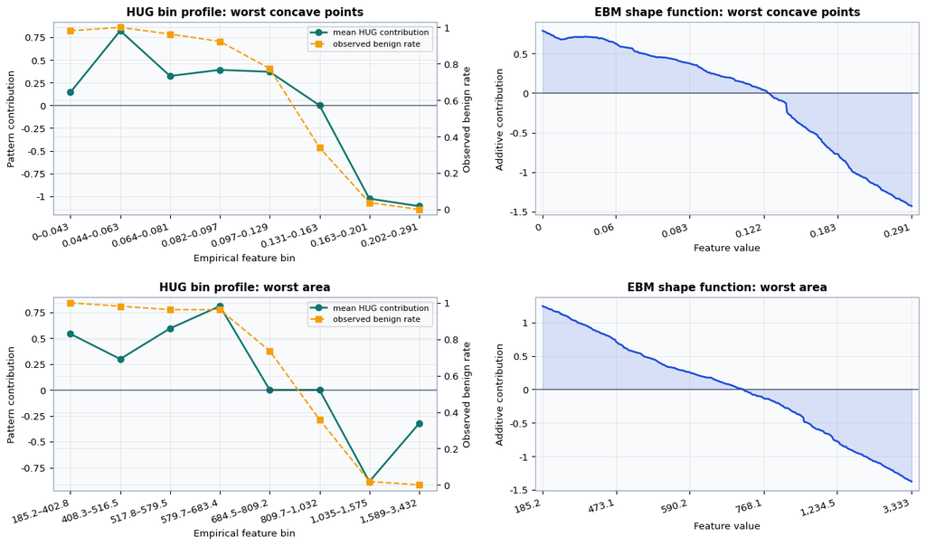

```python
fig, axes = plt.subplots(len(features_for_shape_review), 2, figsize=(12.8, 3.8 * len(features_for_shape_review)))
if len(features_for_shape_review) == 1:
    axes = np.array([axes])

for row_idx, feature in enumerate(features_for_shape_review):
    profile = profiles[feature]
    shape = shapes[feature]
    x_profile = np.arange(len(profile))

    ax = axes[row_idx, 0]
    ax.plot(x_profile, profile["mean_hug_contribution"], marker="o", linewidth=1.8, color=PALETTE["hug"], label="mean HUG contribution")
    ax.axhline(0, linewidth=1, color=PALETTE["neutral"], alpha=0.85)
    ax2 = ax.twinx()
    ax2.plot(x_profile, profile["benign_rate"], marker="s", linestyle="--", linewidth=1.5, color=PALETTE["accent"], label="observed benign rate")
    ax.set_title(f"HUG bin profile: {feature}")
    ax.set_xlabel("Empirical feature bin")
    ax.set_ylabel("Pattern contribution")
    ax2.set_ylabel("Observed benign rate")
    ax.set_xticks(x_profile)
    ax.set_xticklabels(profile["bin_label"], rotation=18, ha="right")
    ax.yaxis.set_major_formatter(FuncFormatter(lambda x, _: clean_number_label(x)))
    ax2.yaxis.set_major_formatter(FuncFormatter(lambda x, _: clean_number_label(x)))
    ax.margins(x=0.03)
    ax2.set_ylim(-0.03, 1.03)
    lines, labels = ax.get_legend_handles_labels()
    lines2, labels2 = ax2.get_legend_handles_labels()
    ax.legend(lines + lines2, labels + labels2, loc="best", fontsize=8, frameon=True)

    ax = axes[row_idx, 1]
    ax.plot(shape["grid_index"], shape["score"], linewidth=1.8, color=PALETTE["ebm"])
    ax.fill_between(shape["grid_index"], 0, shape["score"], alpha=0.15, color=PALETTE["ebm"])
    ax.axhline(0, linewidth=1, color=PALETTE["neutral"], alpha=0.85)
    ax.set_title(f"EBM shape function: {feature}")
    ax.set_xlabel("Feature value")
    ax.set_ylabel("Additive contribution")
    if len(shape) > 8:
        ticks = np.unique(np.linspace(0, len(shape) - 1, 6, dtype=int))
    else:
        ticks = np.arange(len(shape))
    ax.set_xticks(ticks)
    ax.set_xticklabels(shape.loc[ticks, "clean_value"], rotation=18, ha="right")
    ax.yaxis.set_major_formatter(FuncFormatter(lambda x, _: clean_number_label(x)))
    ax.margins(x=0.02)

plt.tight_layout(pad=1.2, w_pad=2.4, h_pad=2.0)
plt.show()
```

### What this comparison adds

HUG profiles make the thresholded pattern representation visible at the feature level. EBM shape functions make the additive curve visible at the same feature level. Reviewing them side by side is useful because:

- a HUG jump near a clinically meaningful range should align with a comparable EBM shape change;
- disagreement can reveal discretization sensitivity, nonlinear behavior, or interaction effects;
- the observed benign-rate overlay helps distinguish model evidence from the empirical class profile.

```python
profile_summary_rows = []
for feature in features_for_shape_review:
    p = profiles[feature]
    s = shapes[feature]
    profile_summary_rows.append({
        "feature": feature,
        "hug_contribution_range": p["mean_hug_contribution"].max() - p["mean_hug_contribution"].min(),
        "ebm_shape_range": s["score"].max() - s["score"].min(),
        "observed_benign_rate_range": p["benign_rate"].max() - p["benign_rate"].min(),
        "hug_bins": len(p),
        "ebm_grid_points": len(s),
    })
pd.DataFrame(profile_summary_rows)
```

|  | feature | hug_contribution_range | ebm_shape_range | observed_benign_rate_range | hug_bins | ebm_grid_points |
| --- | --- | --- | --- | --- | --- | --- |
| 0 | worst concave points | 1.9333 | 2.2192 | 1.0000 | 8 | 380 |
| 1 | worst area | 1.6938 | 2.6191 | 1.0000 | 8 | 413 |

## 7. Same-sample explanation

The selected holdout observation is the case where the HUG and EBM probabilities differ most. That makes it a useful stress case for comparing explanation forms.

```python
comparison = pd.DataFrame({
    "actual_benign": y_test.to_numpy(),
    "hug_probability": hug_score,
    "ebm_probability": ebm_score,
}, index=X_test.index)
comparison["absolute_model_gap"] = (comparison["hug_probability"] - comparison["ebm_probability"]).abs()
selected_index = comparison.sort_values("absolute_model_gap", ascending=False).index[0]
selected_position = list(X_test.index).index(selected_index)

sample = X_test.loc[[selected_index]]
print(f"Selected holdout index: {selected_index}")
print(f"Actual class: {'benign' if int(y_test.loc[selected_index]) == 1 else 'malignant'}")
print(f"HUG probability of benign: {hug_score[selected_position]:.4f}")
print(f"EBM probability of benign: {ebm_score[selected_position]:.4f}")

sample.T.rename(columns={selected_index: "value"}).head(12)
```

```
Selected holdout index: 423
Actual class: benign
HUG probability of benign: 0.4668
EBM probability of benign: 0.9201
```

|  | value |
| --- | --- |
| mean radius | 13.6600 |
| mean texture | 19.1300 |
| mean perimeter | 89.4600 |
| mean area | 575.3000 |
| mean smoothness | 0.0906 |
| mean compactness | 0.1147 |
| mean concavity | 0.0966 |
| mean concave points | 0.0481 |
| mean symmetry | 0.1848 |
| mean fractal dimension | 0.0618 |
| radius error | 0.2244 |
| texture error | 0.8950 |

```python
hug_features = np.array(hug.get_hug_features())
hug_design = hug.transform(sample).toarray()[0]
coef_lookup = hug.feature_importances().set_index("pattern")["coefficient"].to_dict()

fired_patterns = pd.DataFrame({"pattern": hug_features[hug_design > 0]})
fired_patterns["contribution"] = fired_patterns["pattern"].map(coef_lookup)
fired_patterns["direction"] = np.where(fired_patterns["contribution"] >= 0, "toward benign", "toward malignant")
fired_patterns["feature"] = fired_patterns["pattern"].apply(lambda p: extract_feature_from_pattern(p, list(X.columns)))
fired_patterns = fired_patterns.reindex(fired_patterns["contribution"].abs().sort_values(ascending=False).index)

local = ebm.explain_local(sample, pd.Series([y_test.loc[selected_index]], index=sample.index)).data(0)
ebm_local = pd.DataFrame({
    "term": local["names"],
    "value": local["values"],
    "contribution": local["scores"],
})
ebm_local["direction"] = np.where(ebm_local["contribution"] >= 0, "toward benign", "toward malignant")
ebm_local = ebm_local.reindex(ebm_local["contribution"].abs().sort_values(ascending=False).index)

display(fired_patterns.head(12))
display(ebm_local.head(12))
```

|  | pattern | contribution | direction | feature |
| --- | --- | --- | --- | --- |
| 3 | mean smoothness=[0.08613,0.09074) | 0.4849 | toward benign | mean smoothness |
| 0 | worst perimeter=[97.62,107.4) | 0.4074 | toward benign | worst perimeter |
| 1 | mean concave points=[0.03263,0.05256) | 0.1855 | toward benign | mean concave points |
| 4 | radius error=[0.1931,0.2351) | -0.1156 | toward malignant | radius error |
| 2 | worst smoothness=[0.1069,0.1158) | -0.0540 | toward malignant | worst smoothness |
| 6 | area error=[17.82,20.54) | 0.0387 | toward benign | area error |
| 5 | perimeter error=[1.643,1.955) | 0.0352 | toward benign | perimeter error |

|  | term | value | contribution | direction |
| --- | --- | --- | --- | --- |
| 24 | worst smoothness | 0.1147 | 0.4375 | toward benign |
| 26 | worst concavity | 0.3660 | -0.3646 | toward malignant |
| 13 | area error | 19.3600 | 0.2725 | toward benign |
| 10 | radius error | 0.2244 | 0.2428 | toward benign |
| 15 | compactness error | 0.0281 | 0.2315 | toward benign |
| 21 | worst texture | 25.5000 | -0.1865 | toward malignant |
| 18 | symmetry error | 0.0158 | -0.1713 | toward malignant |
| 32 | worst area & worst smoothness |  | 0.1629 | toward benign |
| 1 | mean texture | 19.1300 | -0.1604 | toward malignant |
| 7 | mean concave points | 0.0481 | -0.1402 | toward malignant |
| 5 | mean compactness | 0.1147 | 0.1401 | toward benign |
| 12 | perimeter error | 1.8040 | 0.1366 | toward benign |

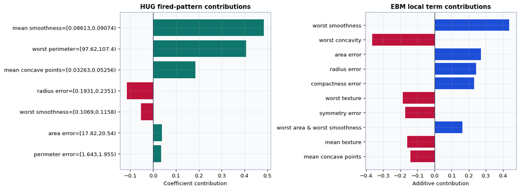

```python
fig, axes = plt.subplots(1, 2, figsize=(13.0, 4.8))
fp = fired_patterns.head(10).iloc[::-1]
el = ebm_local.head(10).iloc[::-1]
axes[0].barh(fp["pattern"], fp["contribution"], color=np.where(fp["contribution"] >= 0, PALETTE["hug"], PALETTE["risk"]))
axes[0].axvline(0, linewidth=1, color=PALETTE["neutral"])
axes[0].set_title("HUG fired-pattern contributions")
axes[0].set_xlabel("Coefficient contribution")
axes[0].set_ylabel("")

axes[1].barh(el["term"], el["contribution"], color=np.where(el["contribution"] >= 0, PALETTE["ebm"], PALETTE["risk"]))
axes[1].axvline(0, linewidth=1, color=PALETTE["neutral"])
axes[1].set_title("EBM local term contributions")
axes[1].set_xlabel("Additive contribution")
axes[1].set_ylabel("")
plt.tight_layout()
plt.show()
```

## 8. Local feature-level reconciliation

The table below aggregates the sample-level evidence by feature where a direct mapping is possible. HUG evidence is summed across fired patterns involving the feature. EBM evidence is the local additive contribution of the same feature term, excluding interaction terms.

```python
hug_local_feature = fired_patterns.dropna(subset=["feature"]).groupby("feature", as_index=False)["contribution"].sum().rename(columns={"contribution": "hug_local_contribution"})
ebm_local_feature = ebm_local[ebm_local["term"].isin(X.columns)][["term", "contribution"]].rename(columns={"term": "feature", "contribution": "ebm_local_contribution"})
local_recon = hug_local_feature.merge(ebm_local_feature, on="feature", how="outer").fillna(0.0)
local_recon["absolute_combined_evidence"] = local_recon["hug_local_contribution"].abs() + local_recon["ebm_local_contribution"].abs()
local_recon = local_recon.sort_values("absolute_combined_evidence", ascending=False)
local_recon.head(12)
```

|  | feature | hug_local_contribution | ebm_local_contribution | absolute_combined_evidence |
| --- | --- | --- | --- | --- |
| 12 | mean smoothness | 0.4849 | -0.0112 | 0.4961 |
| 27 | worst smoothness | -0.0540 | 0.4375 | 0.4915 |
| 25 | worst perimeter | 0.4074 | 0.0304 | 0.4378 |
| 23 | worst concavity | 0.0000 | -0.3646 | 0.3646 |
| 16 | radius error | -0.1156 | 0.2428 | 0.3584 |
| 7 | mean concave points | 0.1855 | -0.1402 | 0.3257 |
| 0 | area error | 0.0387 | 0.2725 | 0.3112 |
| 1 | compactness error | 0.0000 | 0.2315 | 0.2315 |
| 29 | worst texture | 0.0000 | -0.1865 | 0.1865 |
| 15 | perimeter error | 0.0352 | 0.1366 | 0.1718 |
| 18 | symmetry error | 0.0000 | -0.1713 | 0.1713 |
| 14 | mean texture | 0.0000 | -0.1604 | 0.1604 |

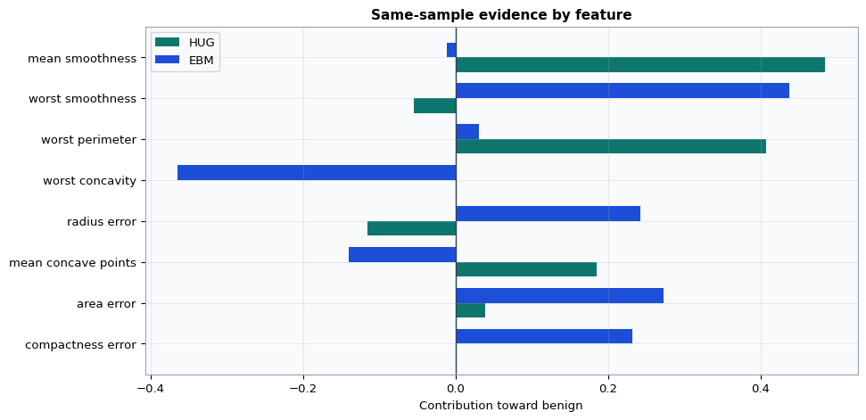

```python
plot_recon = local_recon.head(8).iloc[::-1]
fig, ax = plt.subplots(figsize=(9.8, 4.8))
ypos = np.arange(len(plot_recon))
width = 0.36
ax.barh(ypos - width/2, plot_recon["hug_local_contribution"], height=width, label="HUG", color=PALETTE["hug"])
ax.barh(ypos + width/2, plot_recon["ebm_local_contribution"], height=width, label="EBM", color=PALETTE["ebm"])
ax.axvline(0, linewidth=1, color=PALETTE["neutral"])
ax.set_yticks(ypos)
ax.set_yticklabels(plot_recon["feature"])
ax.set_title("Same-sample evidence by feature")
ax.set_xlabel("Contribution toward benign")
ax.legend()
plt.tight_layout()
plt.show()
```

## 9. Plain-English explanation for the selected sample

```python
def phrase_hug(row):
    return f"{row['pattern']} ({row['direction']}, contribution {row['contribution']:+.3f})"

def phrase_ebm(row):
    val = row["value"] if row["value"] != "" else "interaction"
    return f"{row['term']} = {val} ({row['direction']}, contribution {row['contribution']:+.3f})"

hug_top = fired_patterns.head(5).apply(phrase_hug, axis=1).tolist()
ebm_top = ebm_local.head(5).apply(phrase_ebm, axis=1).tolist()

print("HUG explanation:")
print("The HUG model predicts this case by checking which learned interval patterns fire. The strongest fired signals are:")
for item in hug_top:
    print(" - " + item)
print()
print("EBM explanation:")
print("The EBM prediction is the intercept plus additive feature and interaction contributions. The strongest terms are:")
for item in ebm_top:
    print(" - " + item)
```

```
HUG explanation:
The HUG model predicts this case by checking which learned interval patterns fire. The strongest fired signals are:
 - mean smoothness=[0.08613,0.09074) (toward benign, contribution +0.485)
 - worst perimeter=[97.62,107.4) (toward benign, contribution +0.407)
 - mean concave points=[0.03263,0.05256) (toward benign, contribution +0.185)
 - radius error=[0.1931,0.2351) (toward malignant, contribution -0.116)
 - worst smoothness=[0.1069,0.1158) (toward malignant, contribution -0.054)

EBM explanation:
The EBM prediction is the intercept plus additive feature and interaction contributions. The strongest terms are:
 - worst smoothness = 0.1147 (toward benign, contribution +0.437)
 - worst concavity = 0.366 (toward malignant, contribution -0.365)
 - area error = 19.36 (toward benign, contribution +0.272)
 - radius error = 0.2244 (toward benign, contribution +0.243)
 - compactness error = 0.02809 (toward benign, contribution +0.232)
```

## 10. Governance interpretation

The direct comparison shows two complementary styles of interpretability:

- **HUG-IML** provides compact, rule-like pattern evidence. This is strong for audit inventories, threshold checks, and sample-level firing explanations.
- **EBM** provides additive shape functions. This is strong for reviewing monotonicity, nonlinear feature effects, and term-by-term additive reasoning.
- The bin-profile versus shape-function panels make the comparison richer than a metric-only review: they show whether HUG’s discrete intervals align with EBM’s learned effect curves.
- Local reconciliation helps isolate disagreement. A gap can come from a fired HUG threshold, an EBM univariate curve, or an EBM interaction term.